# Allah-Las Spotify Report

Author

Zsofia Egri

# Let’s talk about Allah-Las!!

[figure not shown]

## Who are they?

Allah-Las is an American garage/surf rock band from Los Angeles, formed in 2008. Their music resembles the music style of the 60’s (but with a touch of modernity).

### Members

The members of the band are:

Miles Michaud (vocals, guitar), Matthew Correia (percussion, vocals), Spencer Dunham (bass, vocals), and Pedrum Siadatian (lead guitar, vocals).

[figure not shown]

### Their Studio Albums:

- 2012 - *Allah-Las*
- 2014 - *Worship the Sun*
- 2016 - *Calico Review*
- 2019 - *LAHS*
- 2023 - *Zuma 85*

## My picks

### My favourite album

Allah-Las (2012)

[figure not shown]

### My favourite song

https://www.youtube.com/watch?v=q6jTzJX0w_g

[video not shown]

### My favourite lyrics:

> It’s been a long long ride,  
> Don’t know where I’ll sleep tonight.

> Oh under the stars  
> Or maybe in your bed alright.

(lyrics from Long Journey)

# Data Analysis

### Data Source

The data is from Spotify, from 2023.

Since the data was downloaded in 2023 it does not contain the tracks of Allah-Las’ most recent album, Zuma 85.

### Importing the Dataset

```r
#loading the needed packages
library(readr)
library(dplyr)
library(ggplot2)
library(knitr)

#importing the data
df <- read.csv("Data_AllahLas.csv")
```

### First Steps

Let’s take a quick glance at the dataset:

```r
#we look at the first 10 rows
kable(head(df, 10))
```

| artist_name | track_name | track_number | album_name | album_release_year | energy | valence | danceability | loudness | speechiness | liveness | tempo | key_mode | duration_ms |
| --- | --- | --- | --- | --- | --- | --- | --- | --- | --- | --- | --- | --- | --- |
| Allah-Las | 200 South La Brea | 9 | Calico Review | 2016 | 0.732 | 0.800 | 0.595 | -7.127 | 0.0299 | 0.0871 | 126.526 | C major | 169986 |
| Allah-Las | 501-415 | 9 | Worship the Sun | 2014 | 0.727 | 0.966 | 0.423 | -5.868 | 0.0480 | 0.1670 | 116.045 | E minor | 103360 |
| Allah-Las | Artifact | 3 | Worship the Sun | 2014 | 0.712 | 0.656 | 0.497 | -5.840 | 0.0301 | 0.1160 | 121.776 | E minor | 213133 |
| Allah-Las | Autumn Dawn | 7 | Calico Review | 2016 | 0.460 | 0.609 | 0.394 | -7.108 | 0.0301 | 0.0963 | 127.543 | E major | 215813 |
| Allah-Las | Better Than Mine | 12 | Worship the Sun | 2014 | 0.731 | 0.947 | 0.328 | -4.884 | 0.0312 | 0.1200 | 186.402 | D major | 169346 |
| Allah-Las | Buffalo Nickel | 7 | Worship the Sun | 2014 | 0.811 | 0.531 | 0.496 | -4.070 | 0.0294 | 0.1500 | 124.494 | A major | 166813 |
| Allah-Las | Busman’s Holiday | 3 | Allah-Las | 2012 | 0.871 | 0.634 | 0.465 | -4.178 | 0.0300 | 0.1710 | 131.901 | A major | 207582 |
| Allah-Las | Catalina | 9 | Allah-Las | 2012 | 0.831 | 0.704 | 0.584 | -6.249 | 0.0280 | 0.0728 | 121.623 | D minor | 223150 |
| Allah-Las | Catamaran | 1 | Allah-Las | 2012 | 0.846 | 0.696 | 0.564 | -5.897 | 0.0437 | 0.0452 | 122.032 | E minor | 212986 |
| Allah-Las | Could Be You | 3 | Calico Review | 2016 | 0.797 | 0.931 | 0.513 | -7.992 | 0.0382 | 0.1240 | 143.414 | E major | 193066 |

Now let’s check if there are any duplicates in our dataframe:

```r
#creating a new df where each row is a unique track
df_unique <- df %>% distinct(track_name, .keep_all = TRUE)

#comparing the number of rows
nrow(df) #51
```

```
[1] 51
```

```r
nrow(df_unique) #51, which means the original dataset contains no duplicates
```

```
[1] 51
```

## Exploratory Data Analysis, Data Visualization

### Every track - Energy and Valence

Let’s start exploring the data by creating a scatterplot using the variables: energy and valence

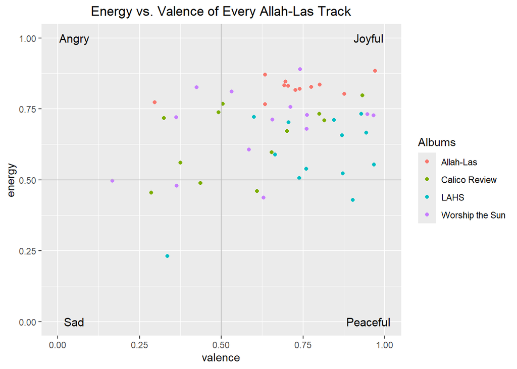

```r
#scatterplot
ggplot(df, aes(x = valence, y = energy, color = album_name)) +
  geom_point() + #visualizing the individual tracks
  xlim(0,1) + #changing the scale to show the entire theoretical range
  ylim(0,1) +
  labs(color = "Albums", title = "Energy vs. Valence of Every Allah-Las Track") +
  theme(plot.title = element_text(hjust = 0.5)) + #changing and adding the labels
  geom_hline(yintercept= 0.5, color="grey") + #creating quartiles
  geom_vline(xintercept= 0.5, color="grey") +
  annotate("text", x = 0.05, y = 1, label = "Angry", size = 4) + #naming quartiles
  annotate("text", x = 0.95, y = 1, label = "Joyful", size = 4) +
  annotate("text", x = 0.05, y = 0, label = "Sad", size = 4) +
  annotate("text", x = 0.95, y = 0, label = "Peaceful", size = 4)
```

Let’s confirm this with some descriptive statistics:

```r
#Some descriptive stats of energy
mean(df$energy) #0.68
```

```
[1] 0.6816863
```

```r
median(df$energy)#0.72
```

```
[1] 0.72
```

```r
#Some descriptive stats of valence
mean(df$valence) #0.67
```

```
[1] 0.6707647
```

```r
median(df$valence) #0.7
```

```
[1] 0.704
```

The mean and median energy and mean and median valence tell the same story as the scatterplot. Allah-Las songs are quite joyful.

Looking at the scatterplot it is quite clear that the most positive and energetic album is Allah-Las (my favourite album), however, we can’t really tell based on the plot how the other 3 albums compare.

Let’s create box-plots to compare the albums based on energy and valence.

Can we notice a pattern? Since the first album was the most joyful does that mean that as the band matures the more recent songs being written are less positive and energetic?

### Albums - Energy and Valence

#### Energy

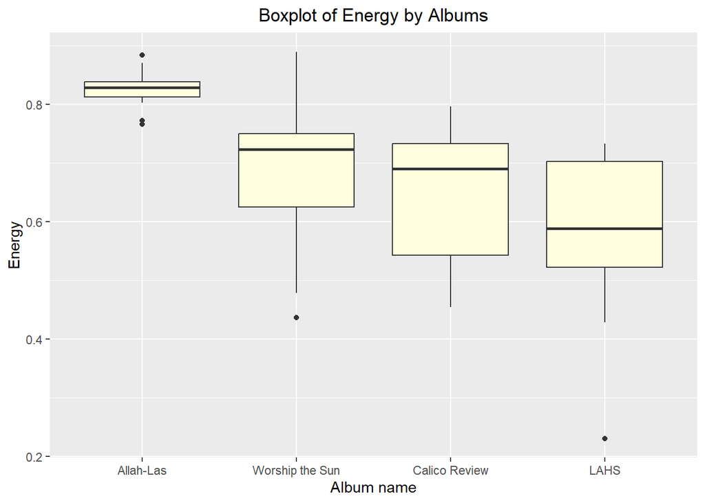

```r
#Boxplot of energy and album_name
ggplot(df, aes(x = factor(album_name, levels = c("Allah-Las", "Worship the Sun", "Calico Review", "LAHS")), y=energy)) +  #chronilogical order of albums with level
  geom_boxplot() +
  labs(x="Album name", y="Energy", title = "Boxplot of Energy by Albums") +
  theme(plot.title = element_text(hjust = 0.5)) +
  geom_boxplot(fill = "lightyellow")
```

It appears that the initial assumption was correct, and each new album is less energetic than the last. This could be a slow but natural change in the band’s music style.

#### Valence

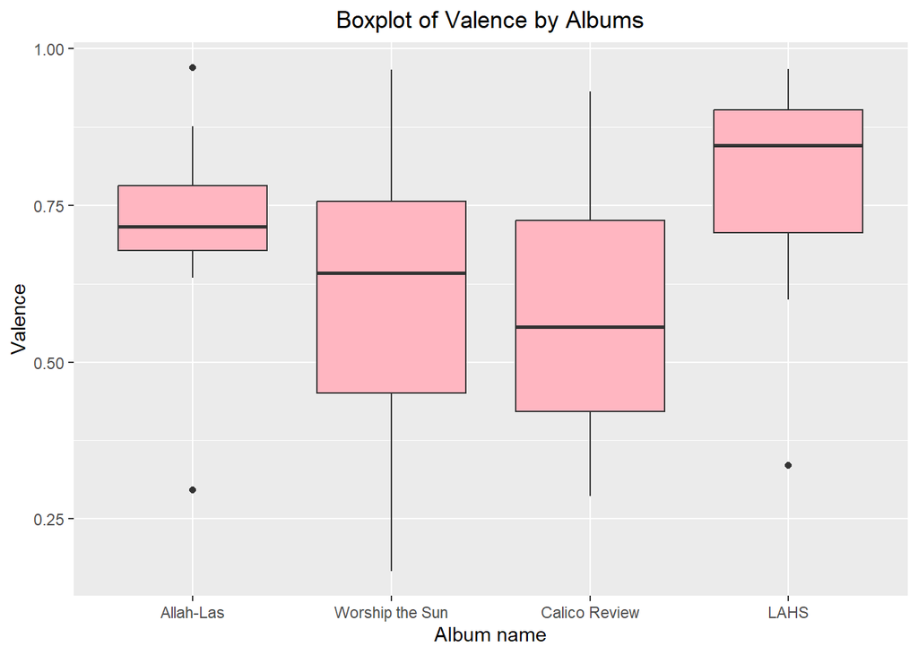

```r
#Boxplot of valence and album name
ggplot(df, aes(x = factor(album_name, levels = c("Allah-Las", "Worship the Sun", "Calico Review", "LAHS")), y=valence)) +  #chronilogical order of albums with level
  geom_boxplot() +
  labs(x="Album name", y="Valence", title = "Boxplot of Valence by Albums") +
  theme(plot.title = element_text(hjust = 0.5)) +
  geom_boxplot(fill = "lightpink")
```

Interestingly, since this wasn’t very visible just by looking at the scatterplot, Allah-Las is not the most positive album. LAHS is noticeably more positive, which contradicts my concept that albums are becoming sadder (less energetic *and* less positive). The trend of albums becoming “sadder” is broken by LAHS, there isn’t really a clear pattern of valence visible, instead it might be better to say that albums are simply becoming calmer and more peaceful.

#### Allas-Las ( the album)

Based on the boxplots of energy and valence we can also see that as the musical career of Allah-Las progressed, the songs they wrote became more diverse within each album. If we look at Allah-Las (the album) we see that the IQRs are very small compared to the other albums, meaning that the tracks are “close to each other” in value. The middle 50% of values are very close, and so most of the songs have very similar characteristics. This is also evident when we listen to the album. Every track in Allah-Las sounds very similar.

Which tracks appear as the three outliers in the energy boxplot?

```r
df_AL <- filter(df, album_name=="Allah-Las")
df_AL |> slice_min(energy, n=2) |> dplyr::select(track_name, energy) |> kable()
```

| track_name | energy |
| --- | --- |
| No Voodoo | 0.766 |
| Sandy | 0.773 |

```r
df_AL |> slice_max(energy, n=1) |> dplyr::select(track_name, energy) |> kable()
```

| track_name | energy |
| --- | --- |
| Long Journey | 0.884 |

If we calculate the range, we get 0.118, which is extremely small.

What tracks appear as outliers in the valence boxplot?

```r
df_AL |> slice_min(valence, n=2) |> dplyr::select(track_name, valence) |> kable()
```

| track_name | valence |
| --- | --- |
| Sandy | 0.296 |
| Busman’s Holiday | 0.634 |
| No Voodoo | 0.634 |

```r
df_AL |> slice_max(valence, n=1) |> dplyr::select(track_name, valence) |> kable()
```

| track_name | valence |
| --- | --- |
| Long Journey | 0.97 |

The range of valence is 0.674 which seems “normal” and appears to be similar compared to the other three albums. However, the second smallest valence belongs to No Voodoo with 0.634, making Sandy quite an extreme outlier. Without Sandy in the album, the range would suddenly become only 0.336.

So on one end of the energy-valence spectrum we find Sandy (and No Vodoo) while on the other we find Long Journey. These are the songs that are the most different from each other in their energy levels and valence.

Now, let’s listen whether we can actually hear a difference!

*Sandy:*

https://www.youtube.com/watch?v=vVdM7JG-qkQ

[video not shown]

*Long Journey:*

https://www.youtube.com/watch?v=Drn7bLP9EBk

[video not shown]

Listening to the two “most different” songs right after each other explains perfectly why the IQRs are so small, and demonstrates the similarity of the tracks in this album.

#### LAHS

How do the most different songs compare in the most recent album of Allah-Las? Is the difference between the variety of songs prominent between the oldest and newest album?

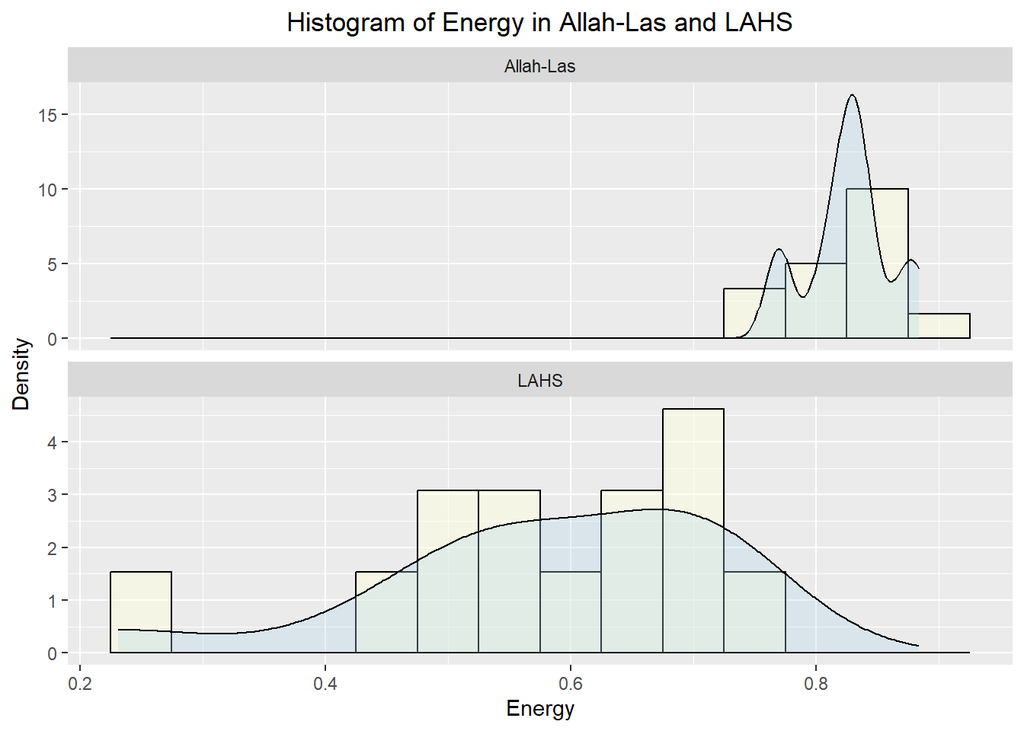

```r
#creating a df with the tracks from LAHS and then a df with both LAHS and Allah-Las
df_LAHS <- filter(df, album_name=="LAHS")
df_comp <- rbind(df_AL, df_LAHS) #df containing only tracks from LAHS and Allah-Las


#Histogram comparing the density of energy in the albums LAHS and Allah-Las
ggplot(df_comp, aes(x = energy, y = after_stat(density))) +
  geom_histogram(binwidth = 0.05, fill = "lightyellow", color = "black", alpha = 0.5) +
  geom_density(alpha = 0.3, fill = "lightblue") + #adding a curve
  facet_wrap(~ album_name, ncol = 1, scales = "free_y") +  #different y scales, stacking
  labs(title = "Histogram of Energy in Allah-Las and LAHS", x = "Energy", y = "Density") + #labeling
  theme(plot.title = element_text(hjust = 0.5)) #title in the middle
```

As the histograms show the tracks in LAHS are more evenly distributed, their energy throughout the album has more variety.

Looking at valence:

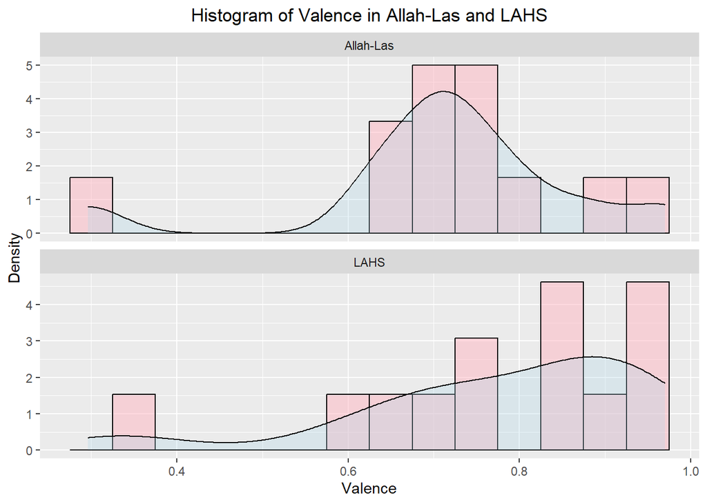

```r
#Histogram comparing the density of valence in the albums LAHS and Allah-Las
ggplot(df_comp, aes(x = valence, y =after_stat(density))) +
  geom_histogram(binwidth = 0.05, fill = "lightpink", color = "black", alpha = 0.5) +
  geom_density(alpha = 0.3, fill="lightblue") + #adding a curve
  facet_wrap(~ album_name, ncol = 1, scales = "free_y") + #different y scales, stacking
  labs(title = "Histogram of Valence in Allah-Las and LAHS", x = "Valence", y = "Density") + #labeling
  theme(plot.title = element_text(hjust = 0.5)) #title in the middle
```

The difference when it comes to valence is definitely smaller than the difference in energy, however, we still see improvement because the curve of LAHS is “flatter”. Valence isn’t as concentrated around one value as it is in the first album.

What are the songs in LAHS that are “furthest apart”?

```r
df_LAHS |> slice_min(energy, n=3) |> dplyr::select(track_name, energy) |> kable()
```

| track_name | energy |
| --- | --- |
| Houston | 0.231 |
| Royal Blues | 0.429 |
| Roco Ono | 0.506 |

```r
df_LAHS |> slice_max(energy, n=3) |> dplyr::select(track_name, energy) |> kable()
```

| track_name | energy |
| --- | --- |
| In the Air | 0.733 |
| On Our Way | 0.721 |
| Polar Onion | 0.711 |

```r
df_LAHS |> slice_max(valence, n=3) |> dplyr::select(track_name, valence) |> kable()
```

| track_name | valence |
| --- | --- |
| Keeping Dry | 0.967 |
| Star | 0.943 |
| In the Air | 0.928 |

```r
df_LAHS |> slice_min(valence, n=3) |> dplyr::select(track_name, valence) |> kable()
```

| track_name | valence |
| --- | --- |
| Houston | 0.335 |
| On Our Way | 0.600 |
| Holding Pattern | 0.665 |

We find Houston and In the Air to be the most different.

Let’s listen to them to find out if we can actually hear the difference!

*Houston:*

https://www.youtube.com/watch?v=LuongBN5sTg

[video not shown]

*In the Air:*

https://www.youtube.com/watch?v=Meuo7BpUOL0

[video not shown]

The difference can be clearly heard! In conclusion we can say that as the band matured and refined their music style they have also created more track diversity within their albums.

### Popularity - Energy and Valence

As of 2025 the five most popular songs based on total listens were:

https://open.spotify.com/artist/2yDodJUwXfdHzg4crwslUp

| Track Name | Album Name | Total Listens |
| --- | --- | --- |
| Catamaran | Allah-Las | 56,962,085 |
| Houston | LAHS | 20,565,975 |
| Ferus Gallery | Worhip the Sun | 15,610,380 |
| No Werewolf | Worhip the Sun | 12,898,926 |
| Star | LAHS | 11,737,070 |

Where are these five songs located in the energy vs. valence scatterplot? Can we see a pattern that might explain popularity? Since the most listened to song, Catamaran, is from the album Allah-Las does that mean that people prefer joyful tracks?

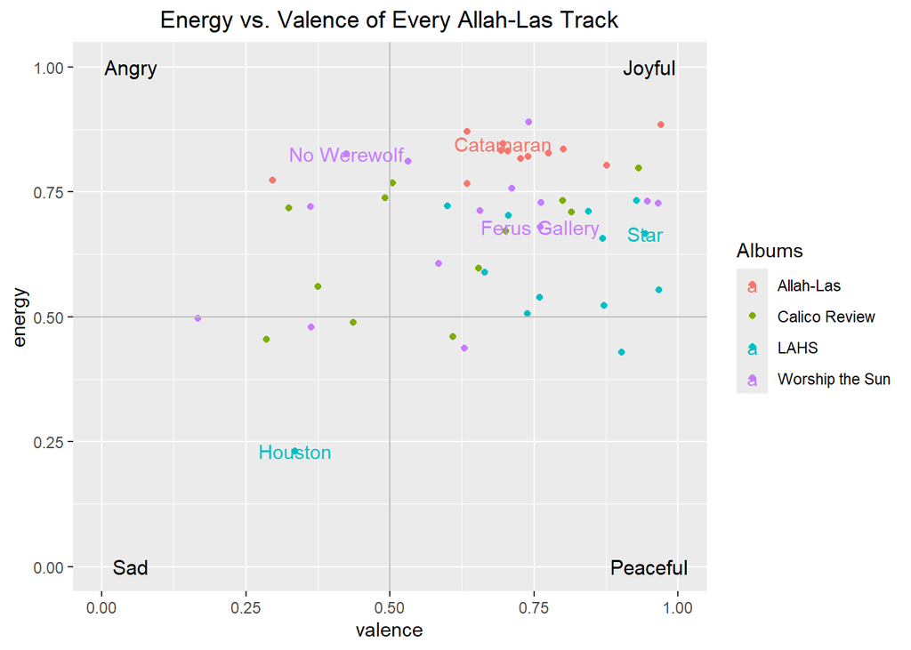

```r
#we create a df with the most listened to songs
df_popular <-df|> filter(track_name%in% c("Catamaran", "Houston", "Ferus Gallery", "No Werewolf", "Star")) #creating a df of popular tracks to add to the scatterplot

#previously used scatter plot + the popular tracks
ggplot(df, aes(x = valence, y = energy, color = album_name)) +
  geom_point() +
  xlim(0,1) +
  ylim(0,1) +
  labs(color = "Albums", title = "Energy vs. Valence of Every Allah-Las Track") +
  theme(plot.title = element_text(hjust = 0.5)) +
  geom_hline(yintercept= 0.5, color="grey") +
  geom_vline(xintercept= 0.5, color="grey") +
  annotate("text", x = 0.05, y = 1, label = "Angry", size = 4) +
  annotate("text", x = 0.95, y = 1, label = "Joyful", size = 4) +
  annotate("text", x = 0.05, y = 0, label = "Sad", size = 4) +
  annotate("text", x = 0.95, y = 0, label = "Peaceful", size = 4) +
  geom_text(data=df_popular, aes(label=track_name)) #adding the popular track names
```

Additionally, joyful songs being over-represented among the most popular songs can simply be because Allah-Las has more positive songs to choose from than angry, sad, or peaceful.

There are multiple reasons why we listen to songs so energy and valence is most likely not enough to explain such a complex question as why some songs become popular and others not.

Let’s take a glance at variables other than energy and valence!

```r
#let's look at the most popular songs' values
kable(df_popular)
```

| artist_name | track_name | track_number | album_name | album_release_year | energy | valence | danceability | loudness | speechiness | liveness | tempo | key_mode | duration_ms |
| --- | --- | --- | --- | --- | --- | --- | --- | --- | --- | --- | --- | --- | --- |
| Allah-Las | Catamaran | 1 | Allah-Las | 2012 | 0.846 | 0.696 | 0.564 | -5.897 | 0.0437 | 0.0452 | 122.032 | E minor | 212986 |
| Allah-Las | Ferus Gallery | 4 | Worship the Sun | 2014 | 0.680 | 0.761 | 0.574 | -7.597 | 0.0305 | 0.0709 | 131.596 | F minor | 215973 |
| Allah-Las | Houston | 12 | LAHS | 2019 | 0.231 | 0.335 | 0.587 | -12.839 | 0.0467 | 0.1060 | 105.921 | B major | 133448 |
| Allah-Las | No Werewolf | 13 | Worship the Sun | 2014 | 0.826 | 0.424 | 0.597 | -4.501 | 0.0535 | 0.1220 | 135.563 | A minor | 148026 |
| Allah-Las | Star | 6 | LAHS | 2019 | 0.666 | 0.943 | 0.657 | -9.525 | 0.0321 | 0.1340 | 73.502 | C major | 248344 |

There doesn’t seem to be anything that truly unites these songs that could explain why they became popular over others.

Still, let’s listen to Catamaran because it’s a truly amazing song:

https://www.youtube.com/watch?v=Zq3cHx0W_RA

[video not shown]

## Conclusions

In conclusion we discovered how Allah-Las’ albums changed as the band gained more experience and came into its own, but the characteristics that explain popularity remained a mystery.

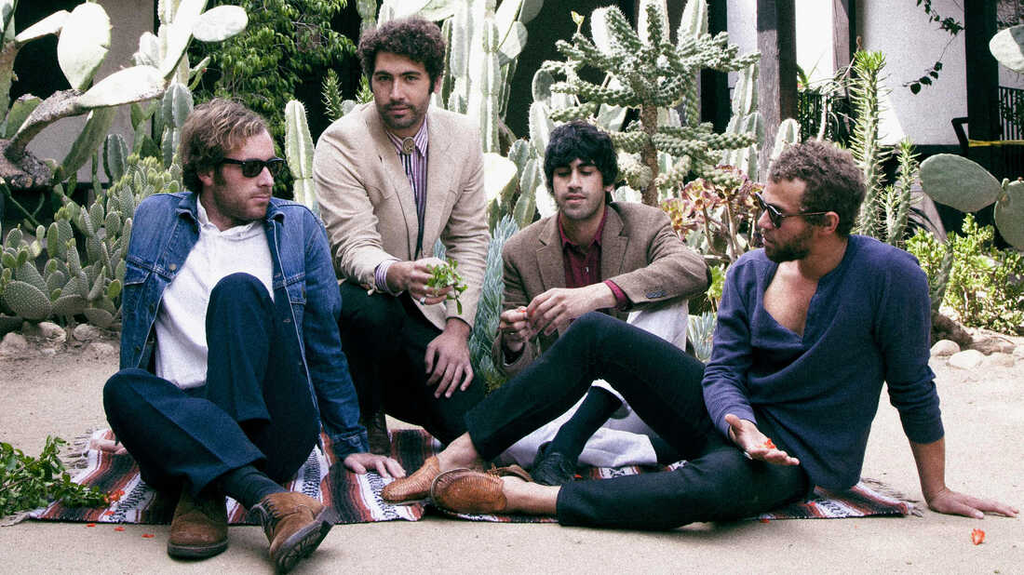